# Assignment 3

# k-NN on Donors Choose Dataset

1. Pre-processing  
   1.1. Pre-processing of project subject category  
   1.2. Pre-processing of project subject sub-category  
   1.3. Text pre-processing
2. Splitting of data
3. Creating data matrix using feature engineering techniques  
   3.1. Bag of Words Encoding  
   3.2. TFIDF Encoding  
   3.3. Avg W2V Encoding  
   3.4. TFIDF W2V Encoding
4. One hot encoding of categorical features  
   4.1. One hot encoding of state  
   4.2. One hot encoding of teacher prefix  
   4.2. One hot encoding of project grade category
5. Normalizing numerical features  
   4.1. Normalizing teacher no. of previously posted projects  
   4.2. Normalizing price
6. Concatinating all features  
   6.1. Concatinating features for BoW  
   6.2. Concatinating features for TFIDF  
   6.3. Concatinating features for AVG W2V  
   6.4. Concatinating features for TFIDF W2V
7. Applying k-NN  
   7.1. Set-1 categorical, numerical features + project_title(BOW) + preprocessed_essay (BOW)  
   7.2. Set-2 categorical, numerical features + project_title(TFIDF) + preprocessed_essay (TFIDF)  
   7.2.1. Selecting the 'K' best features using SelectKBest for Set 2 (TFIDF)  
   7.3. Set-3 categorical, numerical features + project_title(AVG W2V) + preprocessed_essay (AVG W2V)  
   7.4. Set-4 categorical, numerical features + project_title(TFIDF W2V) + preprocessed_essay (TFIDF W2V)
8. Conclusion using PrettyTable Library

## I am considering only the top 50k data-points as my laptop hangs when I use the whole dataset.

```python
#importing all the libraries
%matplotlib inline
import warnings
warnings.filterwarnings("ignore")

import sqlite3
import pandas as pd
import numpy as np
import nltk
import string
import matplotlib.pyplot as plt
import seaborn as sns
from sklearn.feature_extraction.text import TfidfTransformer
from sklearn.feature_extraction.text import TfidfVectorizer

from sklearn.feature_extraction.text import CountVectorizer
from sklearn.metrics import confusion_matrix
from sklearn import metrics
from sklearn.metrics import roc_curve, auc
from nltk.stem.porter import PorterStemmer

import re
# Tutorial about Python regular expressions: https://pymotw.com/2/re/
import string
from nltk.corpus import stopwords
from nltk.stem import PorterStemmer
from nltk.stem.wordnet import WordNetLemmatizer

from gensim.models import Word2Vec
from gensim.models import KeyedVectors
import pickle

from tqdm import tqdm
import os

from plotly import plotly
import plotly.offline as offline
import plotly.graph_objs as go
offline.init_notebook_mode()
from collections import Counter
```

```python
#Loading the dataset
project_data  = pd.read_csv('train_data.csv', nrows=50000)
resource_data = pd.read_csv('resources.csv', nrows=50000)
project_data.head(5)
```

|  | Unnamed: 0 | id | teacher_id | teacher_prefix | school_state | project_submitted_datetime | project_grade_category | project_subject_categories | project_subject_subcategories | project_title | project_essay_1 | project_essay_2 | project_essay_3 | project_essay_4 | project_resource_summary | teacher_number_of_previously_posted_projects | project_is_approved |
| --- | --- | --- | --- | --- | --- | --- | --- | --- | --- | --- | --- | --- | --- | --- | --- | --- | --- |
| 0 | 160221 | p253737 | c90749f5d961ff158d4b4d1e7dc665fc | Mrs. | IN | 2016-12-05 13:43:57 | Grades PreK-2 | Literacy & Language | ESL, Literacy | Educational Support for English Learners at Home | My students are English learners that are work... | \"The limits of your language are the limits o... | NaN | NaN | My students need opportunities to practice beg... | 0 | 0 |
| 1 | 140945 | p258326 | 897464ce9ddc600bced1151f324dd63a | Mr. | FL | 2016-10-25 09:22:10 | Grades 6-8 | History & Civics, Health & Sports | Civics & Government, Team Sports | Wanted: Projector for Hungry Learners | Our students arrive to our school eager to lea... | The projector we need for our school is very c... | NaN | NaN | My students need a projector to help with view... | 7 | 1 |
| 2 | 21895 | p182444 | 3465aaf82da834c0582ebd0ef8040ca0 | Ms. | AZ | 2016-08-31 12:03:56 | Grades 6-8 | Health & Sports | Health & Wellness, Team Sports | Soccer Equipment for AWESOME Middle School Stu... | \r\n\"True champions aren't always the ones th... | The students on the campus come to school know... | NaN | NaN | My students need shine guards, athletic socks,... | 1 | 0 |
| 3 | 45 | p246581 | f3cb9bffbba169bef1a77b243e620b60 | Mrs. | KY | 2016-10-06 21:16:17 | Grades PreK-2 | Literacy & Language, Math & Science | Literacy, Mathematics | Techie Kindergarteners | I work at a unique school filled with both ESL... | My students live in high poverty conditions wi... | NaN | NaN | My students need to engage in Reading and Math... | 4 | 1 |
| 4 | 172407 | p104768 | be1f7507a41f8479dc06f047086a39ec | Mrs. | TX | 2016-07-11 01:10:09 | Grades PreK-2 | Math & Science | Mathematics | Interactive Math Tools | Our second grade classroom next year will be m... | For many students, math is a subject that does... | NaN | NaN | My students need hands on practice in mathemat... | 1 | 1 |

```python
#In the first 50k values we have considered, we have the division of accepted and rejected as follows.
#It can be said that it is an imbalanced dataset
project_data['project_is_approved'].value_counts()
```

```
1    42286
0     7714
Name: project_is_approved, dtype: int64
```

```python
#Adding price to the end of project_data DataFrame
project_data['price'] = resource_data['price']
```

```python
#Using the first 50k values.
y = project_data['project_is_approved'].values
project_data.drop(['project_is_approved'], axis=1, inplace=True)
project_data.head(1)
```

|  | Unnamed: 0 | id | teacher_id | teacher_prefix | school_state | project_submitted_datetime | project_grade_category | project_subject_categories | project_subject_subcategories | project_title | project_essay_1 | project_essay_2 | project_essay_3 | project_essay_4 | project_resource_summary | teacher_number_of_previously_posted_projects | price |
| --- | --- | --- | --- | --- | --- | --- | --- | --- | --- | --- | --- | --- | --- | --- | --- | --- | --- |
| 0 | 160221 | p253737 | c90749f5d961ff158d4b4d1e7dc665fc | Mrs. | IN | 2016-12-05 13:43:57 | Grades PreK-2 | Literacy & Language | ESL, Literacy | Educational Support for English Learners at Home | My students are English learners that are work... | \"The limits of your language are the limits o... | NaN | NaN | My students need opportunities to practice beg... | 0 | 149.0 |

```python
print("Number of data points in train data",project_data.shape)
print('-'*50)
print("The attributes of data :",project_data.columns.values)
print('-'*50)
print("Summary of Data: ",project_data.info())
```

```
Number of data points in train data (50000, 17)
--------------------------------------------------
The attributes of data : ['Unnamed: 0' 'id' 'teacher_id' 'teacher_prefix' 'school_state'
 'project_submitted_datetime' 'project_grade_category'
 'project_subject_categories' 'project_subject_subcategories'
 'project_title' 'project_essay_1' 'project_essay_2' 'project_essay_3'
 'project_essay_4' 'project_resource_summary'
 'teacher_number_of_previously_posted_projects' 'price']
--------------------------------------------------
<class 'pandas.core.frame.DataFrame'>
RangeIndex: 50000 entries, 0 to 49999
Data columns (total 17 columns):
Unnamed: 0                                      50000 non-null int64
id                                              50000 non-null object
teacher_id                                      50000 non-null object
teacher_prefix                                  49998 non-null object
school_state                                    50000 non-null object
project_submitted_datetime                      50000 non-null object
project_grade_category                          50000 non-null object
project_subject_categories                      50000 non-null object
project_subject_subcategories                   50000 non-null object
project_title                                   50000 non-null object
project_essay_1                                 50000 non-null object
project_essay_2                                 50000 non-null object
project_essay_3                                 1685 non-null object
project_essay_4                                 1685 non-null object
project_resource_summary                        50000 non-null object
teacher_number_of_previously_posted_projects    50000 non-null int64
price                                           50000 non-null float64
dtypes: float64(1), int64(2), object(14)
memory usage: 6.5+ MB
Summary of Data:  None
```

```python
# how to replace elements in list python: https://stackoverflow.com/a/2582163/4084039
cols = ['Date' if x=='project_submitted_datetime' else x for x in list(project_data.columns)]

#sort dataframe based on time pandas python: https://stackoverflow.com/a/49702492/4084039
project_data['Date'] = pd.to_datetime(project_data['project_submitted_datetime'])
project_data.drop('project_submitted_datetime', axis=1, inplace=True)
project_data.sort_values(by=['Date'], inplace=True)

# how to reorder columns pandas python: https://stackoverflow.com/a/13148611/4084039
project_data = project_data[cols]

project_data.head(2)
```

|  | Unnamed: 0 | id | teacher_id | teacher_prefix | school_state | Date | project_grade_category | project_subject_categories | project_subject_subcategories | project_title | project_essay_1 | project_essay_2 | project_essay_3 | project_essay_4 | project_resource_summary | teacher_number_of_previously_posted_projects | price |
| --- | --- | --- | --- | --- | --- | --- | --- | --- | --- | --- | --- | --- | --- | --- | --- | --- | --- |
| 473 | 100660 | p234804 | cbc0e38f522143b86d372f8b43d4cff3 | Mrs. | GA | 2016-04-27 00:53:00 | Grades PreK-2 | Applied Learning | Early Development | Flexible Seating for Flexible Learning | I recently read an article about giving studen... | I teach at a low-income (Title 1) school. Ever... | We need a classroom rug that we can use as a c... | Benjamin Franklin once said, \"Tell me and I f... | My students need flexible seating in the class... | 2 | 18.95 |
| 41558 | 33679 | p137682 | 06f6e62e17de34fcf81020c77549e1d5 | Mrs. | WA | 2016-04-27 01:05:25 | Grades 3-5 | Literacy & Language | Literacy | Going Deep: The Art of Inner Thinking! | My students crave challenge, they eat obstacle... | We are an urban, public k-5 elementary school.... | With the new common core standards that have b... | These remarkable gifts will provide students w... | My students need copies of the New York Times ... | 2 | 7.00 |

# 1. Pre-processing

### 1.1 Preprocessing of project subject category

```python
catogories = list(project_data['project_subject_categories'].values)
# remove special characters from list of strings python: https://stackoverflow.com/a/47301924/4084039

# https://www.geeksforgeeks.org/removing-stop-words-nltk-python/
# https://stackoverflow.com/questions/23669024/how-to-strip-a-specific-word-from-a-string
# https://stackoverflow.com/questions/8270092/remove-all-whitespace-in-a-string-in-python
cat_list = []
for i in catogories:
    temp = ""
    # consider we have text like this "Math & Science, Warmth, Care & Hunger"
    for j in i.split(','): # it will split it in three parts ["Math & Science", "Warmth", "Care & Hunger"]
        if 'The' in j.split(): # this will split each of the catogory based on space "Math & Science"=> "Math","&", "Science"
            j=j.replace('The','') # if we have the words "The" we are going to replace it with ''(i.e removing 'The')
        j = j.replace(' ','') # we are placeing all the ' '(space) with ''(empty) ex:"Math & Science"=>"Math&Science"
        temp+=j.strip()+" " #" abc ".strip() will return "abc", remove the trailing spaces
        temp = temp.replace('&','_') # we are replacing the & value into
    cat_list.append(temp.strip())

project_data['clean_categories'] = cat_list
project_data.drop(['project_subject_categories'], axis=1, inplace=True)

from collections import Counter
my_counter = Counter()
for word in project_data['clean_categories'].values:
    my_counter.update(word.split())

cat_dict = dict(my_counter)
sorted_cat_dict = dict(sorted(cat_dict.items(), key=lambda kv: kv[1]))
```

### 1.2 Preprocessing of project subject sub-category

```python
sub_catogories = list(project_data['project_subject_subcategories'].values)
# remove special characters from list of strings python: https://stackoverflow.com/a/47301924/4084039

# https://www.geeksforgeeks.org/removing-stop-words-nltk-python/
# https://stackoverflow.com/questions/23669024/how-to-strip-a-specific-word-from-a-string
# https://stackoverflow.com/questions/8270092/remove-all-whitespace-in-a-string-in-python

sub_cat_list = []
for i in sub_catogories:
    temp = ""
    # consider we have text like this "Math & Science, Warmth, Care & Hunger"
    for j in i.split(','): # it will split it in three parts ["Math & Science", "Warmth", "Care & Hunger"]
        if 'The' in j.split(): # this will split each of the catogory based on space "Math & Science"=> "Math","&", "Science"
            j=j.replace('The','') # if we have the words "The" we are going to replace it with ''(i.e removing 'The')
        j = j.replace(' ','') # we are placeing all the ' '(space) with ''(empty) ex:"Math & Science"=>"Math&Science"
        temp +=j.strip()+" "#" abc ".strip() will return "abc", remove the trailing spaces
        temp = temp.replace('&','_')
    sub_cat_list.append(temp.strip())

project_data['clean_subcategories'] = sub_cat_list
project_data.drop(['project_subject_subcategories'], axis=1, inplace=True)

# count of all the words in corpus python: https://stackoverflow.com/a/22898595/4084039
my_counter = Counter()
for word in project_data['clean_subcategories'].values:
    my_counter.update(word.split())

sub_cat_dict = dict(my_counter)
sorted_sub_cat_dict = dict(sorted(sub_cat_dict.items(), key=lambda kv: kv[1]))
```

### 1.3 Text - preprocessing

```python
#Pre processing of essay.
# merge two column text dataframe:
project_data["essay"] = project_data["project_essay_1"].map(str) +\
                        project_data["project_essay_2"].map(str) + \
                        project_data["project_essay_3"].map(str) + \
                        project_data["project_essay_4"].map(str)
```

```python
# printing some random reviews
print(project_data['essay'].values[0])
print("="*50)
print(project_data['essay'].values[150])
print("="*50)
print(project_data['essay'].values[1000])
print("="*50)
print(project_data['essay'].values[20000])
print("="*50)
```

```
I recently read an article about giving students a choice about how they learn. We already set goals; why not let them choose where to sit, and give them options of what to sit on?I teach at a low-income (Title 1) school. Every year, I have a class with a range of abilities, yet they are all the sam…
==================================================
At the beginning of every class we start out with a Math Application problem to help students see the relevance of topics in math. We are always in groups and do a lot of cooperative activities. We also use lots of technology in our class. I love seeing my students grow and love math!I have a very d…
==================================================
My students love coming to school and they love learning. I strive daily to make our classroom a relaxed, comfortable and welcoming environment where all learners will excel and grow in their learning. And a new rug will make our days even brighter!My 2nd grade classroom is filled with 20 amazing yo…
==================================================
I teach at a Title 1 school, with 73% of my students who receive free/reduced lunch. Our school provides free breakfast for all students. I am a Special Education certified teacher and I teach Kindergarten in a general education setting with my class that consists 52% students with special needs. Th…
==================================================
```

```python
# https://stackoverflow.com/a/47091490/4084039
import re

def decontracted(phrase):
    # specific
    phrase = re.sub(r"won't", "will not", phrase)
    phrase = re.sub(r"can\'t", "can not", phrase)

    # general
    phrase = re.sub(r"n\'t", " not", phrase)
    phrase = re.sub(r"\'re", " are", phrase)
    phrase = re.sub(r"\'s", " is", phrase)
    phrase = re.sub(r"\'d", " would", phrase)
    phrase = re.sub(r"\'ll", " will", phrase)
    phrase = re.sub(r"\'t", " not", phrase)
    phrase = re.sub(r"\'ve", " have", phrase)
    phrase = re.sub(r"\'m", " am", phrase)
    return phrase
```

```python
sent = decontracted(project_data['essay'].values[20000])
print(sent)
print("="*50)
```

```
I teach at a Title 1 school, with 73% of my students who receive free/reduced lunch. Our school provides free breakfast for all students. I am a Special Education certified teacher and I teach Kindergarten in a general education setting with my class that consists 52% students with special needs. Th…
==================================================
```

```python
# \r \n \t remove from string python: http://texthandler.com/info/remove-line-breaks-python/
sent = sent.replace('\\r', ' ')
sent = sent.replace('\\"', ' ')
sent = sent.replace('\\n', ' ')
print(sent)
```

```
I teach at a Title 1 school, with 73% of my students who receive free/reduced lunch. Our school provides free breakfast for all students. I am a Special Education certified teacher and I teach Kindergarten in a general education setting with my class that consists 52% students with special needs. Th…
```

```python
#remove spacial character: https://stackoverflow.com/a/5843547/4084039
sent = re.sub('[^A-Za-z0-9]+', ' ', sent)
print(sent)
```

```
I teach at a Title 1 school with 73 of my students who receive free reduced lunch Our school provides free breakfast for all students I am a Special Education certified teacher and I teach Kindergarten in a general education setting with my class that consists 52 students with special needs The disa…
```

```python
# https://gist.github.com/sebleier/554280
# we are removing the words from the stop words list: 'no', 'nor', 'not'
stopwords= ['i', 'me', 'my', 'myself', 'we', 'our', 'ours', 'ourselves', 'you', "you're", "you've",\
            "you'll", "you'd", 'your', 'yours', 'yourself', 'yourselves', 'he', 'him', 'his', 'himself', \
            'she', "she's", 'her', 'hers', 'herself', 'it', "it's", 'its', 'itself', 'they', 'them', 'their',\
            'theirs', 'themselves', 'what', 'which', 'who', 'whom', 'this', 'that', "that'll", 'these', 'those', \
            'am', 'is', 'are', 'was', 'were', 'be', 'been', 'being', 'have', 'has', 'had', 'having', 'do', 'does', \
            'did', 'doing', 'a', 'an', 'the', 'and', 'but', 'if', 'or', 'because', 'as', 'until', 'while', 'of', \
            'at', 'by', 'for', 'with', 'about', 'against', 'between', 'into', 'through', 'during', 'before', 'after',\
            'above', 'below', 'to', 'from', 'up', 'down', 'in', 'out', 'on', 'off', 'over', 'under', 'again', 'further',\
            'then', 'once', 'here', 'there', 'when', 'where', 'why', 'how', 'all', 'any', 'both', 'each', 'few', 'more',\
            'most', 'other', 'some', 'such', 'only', 'own', 'same', 'so', 'than', 'too', 'very', \
            's', 't', 'can', 'will', 'just', 'don', "don't", 'should', "should've", 'now', 'd', 'll', 'm', 'o', 're', \
            've', 'y', 'ain', 'aren', "aren't", 'couldn', "couldn't", 'didn', "didn't", 'doesn', "doesn't", 'hadn',\
            "hadn't", 'hasn', "hasn't", 'haven', "haven't", 'isn', "isn't", 'ma', 'mightn', "mightn't", 'mustn',\
            "mustn't", 'needn', "needn't", 'shan', "shan't", 'shouldn', "shouldn't", 'wasn', "wasn't", 'weren', "weren't", \
            'won', "won't", 'wouldn', "wouldn't"]
```

```python
# Combining all the above stundents
from tqdm import tqdm
preprocessed_essays = []
# tqdm is for printing the status bar
for sentance in tqdm(project_data['essay'].values):
    sent = decontracted(sentance)
    sent = sent.replace('\\r', ' ')
    sent = sent.replace('\\"', ' ')
    sent = sent.replace('\\n', ' ')
    sent = re.sub('[^A-Za-z0-9]+', ' ', sent)
    # https://gist.github.com/sebleier/554280
    sent = ' '.join(e for e in sent.split() if e.lower() not in stopwords)
    preprocessed_essays.append(sent.lower().strip())
```

```python
#preprocessing of project title.
from tqdm import tqdm
preprocessed_title = []
# tqdm is for printing the status bar
for sentance in tqdm(project_data['project_title'].values):
    sent = decontracted(sentance)
    sent = sent.replace('\\r', ' ')
    sent = sent.replace('\\"', ' ')
    sent = sent.replace('\\n', ' ')
    sent = re.sub('[^A-Za-z0-9]+', ' ', sent)
    # https://gist.github.com/sebleier/554280
    sent = ' '.join(e for e in sent.split() if e.lower() not in stopwords)
    preprocessed_title.append(sent.lower().strip())
```

```python
# preprocessing school state.
from tqdm import tqdm
preprocessed_school_state = []
# tqdm is for printing the status bar
for sentance in tqdm(project_data['school_state'].values):
    sent = decontracted(sentance)
    sent = sent.replace('\\r', ' ')
    sent = sent.replace('\\"', ' ')
    sent = sent.replace('\\n', ' ')
    sent = re.sub('[^A-Za-z0-9]+', ' ', sent)
    # https://gist.github.com/sebleier/554280
    sent = ' '.join(e for e in sent.split() if e.lower() not in stopwords)
    preprocessed_school_state.append(sent.lower().strip())
```

```python
#teacher prefix contains null values.
project_data["teacher_prefix"].fillna("NotMentioned", inplace = True)

# preprocessing teacher-prefix.
from tqdm import tqdm
preprocessed_teacher_prefix = []
# tqdm is for printing the status bar
for sentance in tqdm(project_data['teacher_prefix'].values):
    sent = decontracted(sentance)
    sent = sent.replace('\\r', ' ')
    sent = sent.replace('\\"', ' ')
    sent = sent.replace('\\n', ' ')
    sent = re.sub('[^A-Za-z0-9]+', ' ', sent)
    # https://gist.github.com/sebleier/554280
    sent = ' '.join(e for e in sent.split() if e.lower() not in stopwords)
    preprocessed_teacher_prefix.append(sent.lower().strip())
```

```python
# preprocessing project_grade_category.
from tqdm import tqdm
preprocessed_projgrad_cat = []
# tqdm is for printing the status bar
for sentance in tqdm(project_data['project_grade_category'].values):
    sent = decontracted(sentance)
    sent = sent.replace('\\r', ' ')
    sent = sent.replace('\\"', ' ')
    sent = sent.replace('\\n', ' ')
    sent = re.sub('[^A-Za-z0-9]+', ' ', sent)
    # https://gist.github.com/sebleier/554280
    sent = ' '.join(e for e in sent.split() if e.lower() not in stopwords)
    preprocessed_projgrad_cat.append(sent.lower().strip())
```

```python
#Replacing actual column values with the preprocessed ones.
project_data['project_title'] = preprocessed_title
project_data['essay'] = preprocessed_essays
project_data['school_state'] = preprocessed_school_state
project_data['teacher_prefix'] = preprocessed_teacher_prefix
project_data['project_grade_category'] = preprocessed_projgrad_cat
```

```python
project_data.head(3)
```

|  | Unnamed: 0 | id | teacher_id | teacher_prefix | school_state | Date | project_grade_category | project_title | project_essay_1 | project_essay_2 | project_essay_3 | project_essay_4 | project_resource_summary | teacher_number_of_previously_posted_projects | price | clean_categories | clean_subcategories | essay |
| --- | --- | --- | --- | --- | --- | --- | --- | --- | --- | --- | --- | --- | --- | --- | --- | --- | --- | --- |
| 473 | 100660 | p234804 | cbc0e38f522143b86d372f8b43d4cff3 | mrs | ga | 2016-04-27 00:53:00 | grades prek 2 | flexible seating flexible learning | I recently read an article about giving studen... | I teach at a low-income (Title 1) school. Ever... | We need a classroom rug that we can use as a c... | Benjamin Franklin once said, \"Tell me and I f... | My students need flexible seating in the class... | 2 | 18.95 | AppliedLearning | EarlyDevelopment | recently read article giving students choice l... |
| 41558 | 33679 | p137682 | 06f6e62e17de34fcf81020c77549e1d5 | mrs | wa | 2016-04-27 01:05:25 | grades 3 5 | going deep art inner thinking | My students crave challenge, they eat obstacle... | We are an urban, public k-5 elementary school.... | With the new common core standards that have b... | These remarkable gifts will provide students w... | My students need copies of the New York Times ... | 2 | 7.00 | Literacy_Language | Literacy | students crave challenge eat obstacles breakfa... |
| 29891 | 146723 | p099708 | c0a28c79fe8ad5810da49de47b3fb491 | mrs | ca | 2016-04-27 01:10:09 | grades 3 5 | breakout box ignite engagement | It's the end of the school year. Routines have... | My students desire challenges, movement, and c... | I will design different clues using specific c... | Donations to this project will immediately imp... | My students need items from a \"Breakout Box\"... | 6 | 5.72 | Math_Science History_Civics | Mathematics SocialSciences | end school year routines run course students n... |

```python
#Since we have summed essay into one. We dont need 4 essays.
#Citation: pandas drop a column
#url: https://stackoverflow.com/questions/13411544/delete-column-from-pandas-dataframe-by-column-name
columns = ['project_essay_1', 'project_essay_2', 'project_essay_3', 'project_essay_4']
project_data.drop(columns, axis=1, inplace=True)
```

```python
#We wont be needing these columns.
project_data.drop('Unnamed: 0', axis=1, inplace=True)
project_data.drop('id', axis=1, inplace=True)
project_data.drop('teacher_id', axis=1, inplace=True)
project_data.drop('project_resource_summary', axis=1, inplace=True)
```

```python
X = project_data
```

```python
X.head(3)
```

|  | teacher_prefix | school_state | Date | project_grade_category | project_title | teacher_number_of_previously_posted_projects | price | clean_categories | clean_subcategories | essay |
| --- | --- | --- | --- | --- | --- | --- | --- | --- | --- | --- |
| 473 | mrs | ga | 2016-04-27 00:53:00 | grades prek 2 | flexible seating flexible learning | 2 | 18.95 | AppliedLearning | EarlyDevelopment | recently read article giving students choice l... |
| 41558 | mrs | wa | 2016-04-27 01:05:25 | grades 3 5 | going deep art inner thinking | 2 | 7.00 | Literacy_Language | Literacy | students crave challenge eat obstacles breakfa... |
| 29891 | mrs | ca | 2016-04-27 01:10:09 | grades 3 5 | breakout box ignite engagement | 6 | 5.72 | Math_Science History_Civics | Mathematics SocialSciences | end school year routines run course students n... |

# 2. Splitting the Data

```python
# train test split before vectorizing or performing any feature engineering techniques
#as doing it before leads to data leakage.
from sklearn.model_selection import train_test_split
X_train, X_test, y_train, y_test = train_test_split(X, y, test_size=0.3, stratify=y)
X_train, X_cv, y_train, y_cv = train_test_split(X_train, y_train, test_size=0.3, stratify=y_train)
```

# 3. Creating Data Matrix using Feature Engineering Techniques.

### 3.1 Bag Of Words Encoding

```python
#BoW for essay.
print(X_train.shape, y_train.shape)
print(X_cv.shape, y_cv.shape)
print(X_test.shape, y_test.shape)

print("="*100)

from sklearn.feature_extraction.text import CountVectorizer
vectorizer = CountVectorizer(min_df=10,ngram_range=(1,4), max_features=2000)
vectorizer.fit(X_train['essay'].values) # fit has to happen only on train data

# we use the fitted CountVectorizer to convert the text to vector
X_train_essay_bow = vectorizer.transform(X_train['essay'].values)
X_cv_essay_bow = vectorizer.transform(X_cv['essay'].values)
X_test_essay_bow = vectorizer.transform(X_test['essay'].values)

print("After vectorizations")
print(X_train_essay_bow.shape, y_train.shape)
print(X_cv_essay_bow.shape, y_cv.shape)
print(X_test_essay_bow.shape, y_test.shape)
```

```
(24500, 10) (24500,)
(10500, 10) (10500,)
(15000, 10) (15000,)
====================================================================================================
After vectorizations
(24500, 2000) (24500,)
(10500, 2000) (10500,)
(15000, 2000) (15000,)
```

```python
#BoW for project-title.

from sklearn.feature_extraction.text import CountVectorizer
vectorizer = CountVectorizer(min_df=10,ngram_range=(1,4), max_features=5000)
vectorizer.fit(X_train['project_title'].values) # fit has to happen only on train data

# we use the fitted CountVectorizer to convert the text to vector
X_train_title_bow = vectorizer.transform(X_train['project_title'].values)
X_cv_title_bow = vectorizer.transform(X_cv['project_title'].values)
X_test_title_bow = vectorizer.transform(X_test['project_title'].values)

print("After vectorizations")
print(X_train_title_bow.shape, y_train.shape)
print(X_cv_title_bow.shape, y_cv.shape)
print(X_test_title_bow.shape, y_test.shape)
```

[output not shown]

### 3.2 TF-IDF Encoding

```python
#TF-IDF Encoding on project essay
from sklearn.feature_extraction.text import TfidfVectorizer
vectorizer_essay_tfidf = TfidfVectorizer(min_df=10, ngram_range=(1,4), max_features=2000)
vectorizer_essay_tfidf.fit(X_train['essay'].values) # fit has to happen only on train data

# we use the fitted CountVectorizer to convert the text to vector
X_train_essay_tfidf = vectorizer_essay_tfidf.transform(X_train['essay'].values)
X_cv_essay_tfidf = vectorizer_essay_tfidf.transform(X_cv['essay'].values)
X_test_essay_tfidf = vectorizer_essay_tfidf.transform(X_test['essay'].values)

print("After vectorizations")
print(X_train_essay_tfidf.shape, y_train.shape)
print(X_cv_essay_tfidf.shape, y_cv.shape)
print(X_test_essay_tfidf.shape, y_test.shape)
```

```
After vectorizations
(24500, 2000) (24500,)
(10500, 2000) (10500,)
(15000, 2000) (15000,)
```

```python
#TF-IDF Encoding on project title

from sklearn.feature_extraction.text import TfidfVectorizer
vectorizer_title_tfidf = CountVectorizer(min_df=10,ngram_range=(1,4), max_features=2000)
vectorizer_title_tfidf.fit(X_train['project_title'].values) # fit has to happen only on train data

# we use the fitted CountVectorizer to convert the text to vector
X_train_title_tfidf = vectorizer_title_tfidf.transform(X_train['project_title'].values)
X_cv_title_tfidf = vectorizer_title_tfidf.transform(X_cv['project_title'].values)
X_test_title_tfidf = vectorizer_title_tfidf.transform(X_test['project_title'].values)

print("After vectorizations")
print(X_train_title_tfidf.shape, y_train.shape)
print(X_cv_title_tfidf.shape, y_cv.shape)
print(X_test_title_tfidf.shape, y_test.shape)
```

```
After vectorizations
(24500, 1811) (24500,)
(10500, 1811) (10500,)
(15000, 1811) (15000,)
```

### 3.3 AVG W2V Encoding

```python
#ON PRE-PROCESSED ESSAY
# stronging variables into pickle files python: http://www.jessicayung.com/how-to-use-pickle-to-save-and-load-variables-in-python/
# make sure you have the glove_vectors file
with open('glove_vectors', 'rb') as f:
    model = pickle.load(f)
    glove_words =  set(model.keys())
```

```python
#Train part of preprocessed essays.
train_w2v_vectors_essays = []; # the avg-w2v for each essay is stored in this list
for sentence in tqdm(X_train['essay'].values): # for each essay in training data
    vector = np.zeros(300) # as word vectors are of zero length
    cnt_words =0; # num of words with a valid vector in the essay
    for word in sentence.split(): # for each word in a essay
        if word in glove_words:
            vector += model[word]
            cnt_words += 1
    if cnt_words != 0:
        vector /= cnt_words
    train_w2v_vectors_essays.append(vector)
print("Train Vector for essay")
print(len(train_w2v_vectors_essays))
print(len(train_w2v_vectors_essays[0]))
```

```
Train Vector for essay
24500
300
```

```python
#Test part of preprocessed essays.
# average Word2Vec
# compute average word2vec for each review.
test_w2v_vectors_essays = []; # the avg-w2v for each essay is stored in this list
for sentence in tqdm(X_test['essay'].values): # for each essay in training data
    vector = np.zeros(300) # as word vectors are of zero length
    cnt_words =0; # num of words with a valid vector in the essay
    for word in sentence.split(): # for each word in a essay
        if word in glove_words:
            vector += model[word]
            cnt_words += 1
    if cnt_words != 0:
        vector /= cnt_words
    test_w2v_vectors_essays.append(vector)

print("Test Vector for essay")
print(len(test_w2v_vectors_essays))
print(len(test_w2v_vectors_essays[0]))
```

```
Test Vector for essay
15000
300
```

```python
#CV part of preprocessed essays.
# average Word2Vec
# compute average word2vec for each review.
cv_w2v_vectors_essays = []; # the avg-w2v for each essay is stored in this list
for sentence in tqdm(X_cv['essay'].values): # for each essay in training data
    vector = np.zeros(300) # as word vectors are of zero length
    cnt_words =0; # num of words with a valid vector in the essay
    for word in sentence.split(): # for each word in a essay
        if word in glove_words:
            vector += model[word]
            cnt_words += 1
    if cnt_words != 0:
        vector /= cnt_words
    cv_w2v_vectors_essays.append(vector)

print("CV vector for essay")
print(len(cv_w2v_vectors_essays))
print(len(cv_w2v_vectors_essays[0]))
```

```
CV vector for essay
10500
300
```

```python
# Changing the lists (Train, Test, CV) to numpy arrays
train_w2v_vectors_essays = np.array(train_w2v_vectors_essays)
test_w2v_vectors_essays = np.array(test_w2v_vectors_essays)
cv_w2v_vectors_essays = np.array(cv_w2v_vectors_essays)
```

```python
#Following the same process for preprocessed titles.
# average Word2Vec
# compute average word2vec for each review.
w2v_train_vectors_titles = []; # the avg-w2v for each essay is stored in this list
for sentence in tqdm(X_train['project_title'].values): # for each essay in training data
    vector = np.zeros(300) # as word vectors are of zero length
    cnt_words =0; # num of words with a valid vector in the essay
    for word in sentence.split(): # for each word in a essay
        if word in glove_words:
            vector += model[word]
            cnt_words += 1
    if cnt_words != 0:
        vector /= cnt_words
    w2v_train_vectors_titles.append(vector)
print("Train Vector for project title")
print(len(w2v_train_vectors_titles))
print(len(w2v_train_vectors_titles[0]))

# average Word2Vec
# compute average word2vec for each review.
w2v_test_vectors_titles = []; # the avg-w2v for each essay is stored in this list
for sentence in tqdm(X_test['project_title'].values): # for each essay in training data
    vector = np.zeros(300) # as word vectors are of zero length
    cnt_words =0; # num of words with a valid vector in the essay
    for word in sentence.split(): # for each word in a essay
        if word in glove_words:
            vector += model[word]
            cnt_words += 1
    if cnt_words != 0:
        vector /= cnt_words
    w2v_test_vectors_titles.append(vector)

print("Test Vector for project title")
print(len(w2v_test_vectors_titles))
print(len(w2v_test_vectors_titles[0]))

# average Word2Vec
# compute average word2vec for each review.
w2v_cv_vectors_titles = []; # the avg-w2v for each essay is stored in this list
for sentence in tqdm(X_cv['project_title'].values): # for each essay in training data
    vector = np.zeros(300) # as word vectors are of zero length
    cnt_words =0; # num of words with a valid vector in the essay
    for word in sentence.split(): # for each word in a essay
        if word in glove_words:
            vector += model[word]
            cnt_words += 1
    if cnt_words != 0:
        vector /= cnt_words
    w2v_cv_vectors_titles.append(vector)

print("CV Vector for project title")
print(len(w2v_cv_vectors_titles))
print(len(w2v_cv_vectors_titles[0]))
```

```
Train Vector for project title
24500
300
```

```
Test Vector for project title
15000
300
```

```
CV Vector for project title
10500
300
```

### 3.4 TFIDF weighted W2V Encoding

```python
# S = ["abc def pqr", "def def def abc", "pqr pqr def"]
tfidf_model = TfidfVectorizer()
tfidf_model.fit(preprocessed_essays)

# we are converting a dictionary with word as a key, and the idf as a value
dictionary = dict(zip(tfidf_model.get_feature_names(), list(tfidf_model.idf_)))
tfidf_words = set(tfidf_model.get_feature_names())
```

```python
#ON PRE-PROCESSED ESSAY
# stronging variables into pickle files python: http://www.jessicayung.com/how-to-use-pickle-to-save-and-load-variables-in-python/
# make sure you have the glove_vectors file
with open('glove_vectors', 'rb') as f:
    model = pickle.load(f)
    glove_words =  set(model.keys())

train_tfidf_w2v_essay = []; # the avg-w2v for each sentence/review is stored in this list
for sentence in tqdm(X_train['essay']): # for each review/sentence
    vector = np.zeros(300) # as word vectors are of zero length
    tf_idf_weight =0; # num of words with a valid vector in the sentence/review
    for word in sentence.split(): # for each word in a review/sentence
        if (word in glove_words) and (word in tfidf_words):
            vec = model[word] # getting the vector for each word
            # here we are multiplying idf value(dictionary[word]) and the tf value((sentence.count(word)/len(sentence.split())))
            tf_idf = dictionary[word]*(sentence.count(word)/len(sentence.split())) # getting the tfidf value for each word
            vector += (vec * tf_idf) # calculating tfidf weighted w2v
            tf_idf_weight += tf_idf
    if tf_idf_weight != 0:
        vector /= tf_idf_weight
    train_tfidf_w2v_essay.append(vector)

print(len(train_tfidf_w2v_essay))
print(len(train_tfidf_w2v_essay[0]))
```

```
24500
300
```

```python
cv_tfidf_w2v_essay = []; # the avg-w2v for each sentence/review is stored in this list
for sentence in tqdm(X_cv['essay']): # for each review/sentence
    vector = np.zeros(300) # as word vectors are of zero length
    tf_idf_weight =0; # num of words with a valid vector in the sentence/review
    for word in sentence.split(): # for each word in a review/sentence
        if (word in glove_words) and (word in tfidf_words):
            vec = model[word] # getting the vector for each word
            # here we are multiplying idf value(dictionary[word]) and the tf value((sentence.count(word)/len(sentence.split())))
            tf_idf = dictionary[word]*(sentence.count(word)/len(sentence.split())) # getting the tfidf value for each word
            vector += (vec * tf_idf) # calculating tfidf weighted w2v
            tf_idf_weight += tf_idf
    if tf_idf_weight != 0:
        vector /= tf_idf_weight
    cv_tfidf_w2v_essay.append(vector)

print(len(cv_tfidf_w2v_essay))
print(len(cv_tfidf_w2v_essay[0]))
```

```
10500
300
```

```python
test_tfidf_w2v_essay = []; # the avg-w2v for each sentence/review is stored in this list
for sentence in tqdm(X_test['essay']): # for each review/sentence
    vector = np.zeros(300) # as word vectors are of zero length
    tf_idf_weight =0; # num of words with a valid vector in the sentence/review
    for word in sentence.split(): # for each word in a review/sentence
        if (word in glove_words) and (word in tfidf_words):
            vec = model[word] # getting the vector for each word
            # here we are multiplying idf value(dictionary[word]) and the tf value((sentence.count(word)/len(sentence.split())))
            tf_idf = dictionary[word]*(sentence.count(word)/len(sentence.split())) # getting the tfidf value for each word
            vector += (vec * tf_idf) # calculating tfidf weighted w2v
            tf_idf_weight += tf_idf
    if tf_idf_weight != 0:
        vector /= tf_idf_weight
    test_tfidf_w2v_essay.append(vector)

print(len(test_tfidf_w2v_essay))
print(len(test_tfidf_w2v_essay[0]))
```

```
15000
300
```

```python
# Changing list to numpy arrays
train_tfidf_w2v_essay = np.array(train_tfidf_w2v_essay)
test_tfidf_w2v_essay = np.array(test_tfidf_w2v_essay)
cv_tfidf_w2v_essay = np.array(cv_tfidf_w2v_essay)
```

```python
tfidf_model = TfidfVectorizer()
tfidf_model.fit(preprocessed_title)

# we are converting a dictionary with word as a key, and the idf as a value
dictionary = dict(zip(tfidf_model.get_feature_names(), list(tfidf_model.idf_)))
tfidf_words = set(tfidf_model.get_feature_names())

#ON PREPROCESSED TITLE
train_tfidf_w2v_title = []; # the avg-w2v for each sentence/review is stored in this list
for sentence in tqdm(X_train['project_title']): # for each review/sentence
    vector = np.zeros(300) # as word vectors are of zero length
    tf_idf_weight =0; # num of words with a valid vector in the sentence/review
    for word in sentence.split(): # for each word in a review/sentence
        if (word in glove_words) and (word in tfidf_words):
            vec = model[word] # getting the vector for each word
            # here we are multiplying idf value(dictionary[word]) and the tf value((sentence.count(word)/len(sentence.split())))
            tf_idf = dictionary[word]*(sentence.count(word)/len(sentence.split())) # getting the tfidf value for each word
            vector += (vec * tf_idf) # calculating tfidf weighted w2v
            tf_idf_weight += tf_idf
    if tf_idf_weight != 0:
        vector /= tf_idf_weight
    train_tfidf_w2v_title.append(vector)

print(len(train_tfidf_w2v_title))
print(len(train_tfidf_w2v_title[0]))

cv_tfidf_w2v_title = []; # the avg-w2v for each sentence/review is stored in this list
for sentence in tqdm(X_cv['project_title']): # for each review/sentence
    vector = np.zeros(300) # as word vectors are of zero length
    tf_idf_weight =0; # num of words with a valid vector in the sentence/review
    for word in sentence.split(): # for each word in a review/sentence
        if (word in glove_words) and (word in tfidf_words):
            vec = model[word] # getting the vector for each word
            # here we are multiplying idf value(dictionary[word]) and the tf value((sentence.count(word)/len(sentence.split())))
            tf_idf = dictionary[word]*(sentence.count(word)/len(sentence.split())) # getting the tfidf value for each word
            vector += (vec * tf_idf) # calculating tfidf weighted w2v
            tf_idf_weight += tf_idf
    if tf_idf_weight != 0:
        vector /= tf_idf_weight
    cv_tfidf_w2v_title.append(vector)

print(len(cv_tfidf_w2v_title))
print(len(cv_tfidf_w2v_title[0]))

test_tfidf_w2v_title = []; # the avg-w2v for each sentence/review is stored in this list
for sentence in tqdm(X_test['project_title']): # for each review/sentence
    vector = np.zeros(300) # as word vectors are of zero length
    tf_idf_weight =0; # num of words with a valid vector in the sentence/review
    for word in sentence.split(): # for each word in a review/sentence
        if (word in glove_words) and (word in tfidf_words):
            vec = model[word] # getting the vector for each word
            # here we are multiplying idf value(dictionary[word]) and the tf value((sentence.count(word)/len(sentence.split())))
            tf_idf = dictionary[word]*(sentence.count(word)/len(sentence.split())) # getting the tfidf value for each word
            vector += (vec * tf_idf) # calculating tfidf weighted w2v
            tf_idf_weight += tf_idf
    if tf_idf_weight != 0:
        vector /= tf_idf_weight
    test_tfidf_w2v_title.append(vector)

print(len(test_tfidf_w2v_title))
print(len(test_tfidf_w2v_title[0]))
```

```
24500
300
```

```
10500
300
```

```
15000
300
```

```python
# Changing list to numpy arrays
train_tfidf_w2v_title = np.array(train_tfidf_w2v_title)
test_tfidf_w2v_title = np.array(test_tfidf_w2v_title)
cv_tfidf_w2v_title = np.array(cv_tfidf_w2v_title)
```

# 4. One Hot Encoding of Categorical features.

### 4.1 One Hot Encoding of STATE.

```python
vectorizer = CountVectorizer()
vectorizer.fit(X_train['school_state'].values) # fit has to happen only on train data

# we use the fitted CountVectorizer to convert the text to vector
X_train_state_ohe = vectorizer.transform(X_train['school_state'].values)
X_cv_state_ohe = vectorizer.transform(X_cv['school_state'].values)
X_test_state_ohe = vectorizer.transform(X_test['school_state'].values)

print("After vectorizations")
print(X_train_state_ohe.shape, y_train.shape)
print(X_cv_state_ohe.shape, y_cv.shape)
print(X_test_state_ohe.shape, y_test.shape)
print(vectorizer.get_feature_names())
print("="*100)
```

```
After vectorizations
(24500, 47) (24500,)
(10500, 47) (10500,)
(15000, 47) (15000,)
['ak', 'al', 'ar', 'az', 'ca', 'co', 'ct', 'dc', 'de', 'fl', 'ga', 'hi', 'ia', 'id', 'il', 'ks', 'ky', 'la', 'md', 'mi', 'mn', 'mo', 'ms', 'mt', 'nc', 'nd', 'ne', 'nh', 'nj', 'nm', 'nv', 'ny', 'oh', 'ok', 'pa', 'ri', 'sc', 'sd', 'tn', 'tx', 'ut', 'va', 'vt', 'wa', 'wi', 'wv', 'wy']
====================================================================================================
```

### 4.2 One Hot Encoding of TEACHER-PREFIX.

### NOTE:- Teacher prefix contains 2 null values and OHE cannot be performed on NaN values. Hence I have filled the two NaN values using fllna() with 'Not Mentioned'

```python
vectorizer = CountVectorizer()
vectorizer.fit(X_train['teacher_prefix'].values) # fit has to happen only on train data

# we use the fitted CountVectorizer to convert the text to vector
X_train_teacher_ohe = vectorizer.transform(X_train['teacher_prefix'].values)
X_cv_teacher_ohe = vectorizer.transform(X_cv['teacher_prefix'].values)
X_test_teacher_ohe = vectorizer.transform(X_test['teacher_prefix'].values)

print("After vectorizations")
print(X_train_teacher_ohe.shape, y_train.shape)
print(X_cv_teacher_ohe.shape, y_cv.shape)
print(X_test_teacher_ohe.shape, y_test.shape)
print(vectorizer.get_feature_names())
print("="*100)
```

```
After vectorizations
(24500, 5) (24500,)
(10500, 5) (10500,)
(15000, 5) (15000,)
['mr', 'mrs', 'ms', 'notmentioned', 'teacher']
====================================================================================================
```

### 4.3 One Hot Encoding of PROJECT_GRADE_CATEGORY.

```python
vectorizer = CountVectorizer()
vectorizer.fit(X_train['project_grade_category'].values) # fit has to happen only on train data

# we use the fitted CountVectorizer to convert the text to vector
X_train_grade_ohe = vectorizer.transform(X_train['project_grade_category'].values)
X_cv_grade_ohe = vectorizer.transform(X_cv['project_grade_category'].values)
X_test_grade_ohe = vectorizer.transform(X_test['project_grade_category'].values)

print("After vectorizations")
print(X_train_grade_ohe.shape, y_train.shape)
print(X_cv_grade_ohe.shape, y_cv.shape)
print(X_test_grade_ohe.shape, y_test.shape)
print(vectorizer.get_feature_names())
print("="*100)
```

```
After vectorizations
(24500, 3) (24500,)
(10500, 3) (10500,)
(15000, 3) (15000,)
['12', 'grades', 'prek']
====================================================================================================
```

# 5. Normalizing numerical features

### 5.1 Normalizing TEACHER NO OF PREV. POSTED PROJ

```python
from sklearn.preprocessing import Normalizer
normalizer = Normalizer()
# normalizer.fit(X_train['price'].values)
# this will rise an error Expected 2D array, got 1D array instead:
# array=[105.22 215.96  96.01 ... 368.98  80.53 709.67].
# Reshape your data either using
# array.reshape(-1, 1) if your data has a single feature
# array.reshape(1, -1)  if it contains a single sample.

normalizer.fit(X_train['teacher_number_of_previously_posted_projects'].values.reshape(-1,1))

X_train_TNPPP_norm = normalizer.transform(X_train['teacher_number_of_previously_posted_projects'].values.reshape(-1,1))
X_cv_TNPPP_norm = normalizer.transform(X_cv['teacher_number_of_previously_posted_projects'].values.reshape(-1,1))
X_test_TNPPP_norm = normalizer.transform(X_test['teacher_number_of_previously_posted_projects'].values.reshape(-1,1))

print("After vectorizations")
print(X_train_TNPPP_norm.shape, y_train.shape)
print(X_cv_TNPPP_norm.shape, y_cv.shape)
print(X_test_TNPPP_norm.shape, y_test.shape)
print("="*100)
```

```
After vectorizations
(24500, 1) (24500,)
(10500, 1) (10500,)
(15000, 1) (15000,)
====================================================================================================
```

### 5.2 Normalizing PRICE

```python
from sklearn.preprocessing import Normalizer
normalizer = Normalizer()
# normalizer.fit(X_train['price'].values)
# this will rise an error Expected 2D array, got 1D array instead:
# array=[105.22 215.96  96.01 ... 368.98  80.53 709.67].
# Reshape your data either using
# array.reshape(-1, 1) if your data has a single feature
# array.reshape(1, -1)  if it contains a single sample.
normalizer.fit(X_train['price'].values.reshape(-1,1))

X_train_price_norm = normalizer.transform(X_train['price'].values.reshape(-1,1))
X_cv_price_norm = normalizer.transform(X_cv['price'].values.reshape(-1,1))
X_test_price_norm = normalizer.transform(X_test['price'].values.reshape(-1,1))

print("After vectorizations")
print(X_train_price_norm.shape, y_train.shape)
print(X_cv_price_norm.shape, y_cv.shape)
print(X_test_price_norm.shape, y_test.shape)
print("="*100)
```

```
After vectorizations
(24500, 1) (24500,)
(10500, 1) (10500,)
(15000, 1) (15000,)
====================================================================================================
```

# 6. Concatinating All Features.

### 6. 1 Concatinating for BoW

**Bag Of Words Encoding of:-**

- Project essay.
- Project title.

**One Hot Encoding of:-**

- State
- Teacher prefix.
- Project Grade Category.

**Normalization of:-**

- Price
- Teacher No. of Prev. posted projects

```python
# merge two sparse matrices: https://stackoverflow.com/a/19710648/4084039
#Concatinating features for BoW
from scipy.sparse import hstack
X_tr = hstack((X_train_essay_bow, X_train_title_bow, X_train_state_ohe, X_train_teacher_ohe, X_train_grade_ohe, X_train_TNPPP_norm, X_train_price_norm)).tocsr()
X_cr = hstack((X_cv_essay_bow, X_cv_title_bow, X_cv_state_ohe, X_cv_teacher_ohe, X_cv_grade_ohe, X_cv_TNPPP_norm, X_cv_price_norm)).tocsr()
X_te = hstack((X_test_essay_bow, X_test_title_bow, X_test_state_ohe, X_test_teacher_ohe, X_test_grade_ohe, X_test_TNPPP_norm, X_test_price_norm)).tocsr()

print("Final Data matrix")
print(X_tr.shape, y_train.shape)
print(X_cr.shape, y_cv.shape)
print(X_te.shape, y_test.shape)
print("="*100)
```

[output not shown]

### 6. 2 Concatinating for TF-IDF

```python
#Concatinating features for TFIDF
from scipy.sparse import hstack
X_tr = hstack((X_train_essay_tfidf, X_train_title_tfidf, X_train_state_ohe, X_train_teacher_ohe, X_train_grade_ohe, X_train_TNPPP_norm, X_train_price_norm)).tocsr()
X_cr = hstack((X_cv_essay_tfidf, X_cv_title_tfidf, X_cv_state_ohe, X_cv_teacher_ohe, X_cv_grade_ohe, X_cv_TNPPP_norm, X_cv_price_norm)).tocsr()
X_te = hstack((X_test_essay_tfidf, X_test_title_tfidf, X_test_state_ohe, X_test_teacher_ohe, X_test_grade_ohe, X_test_TNPPP_norm, X_test_price_norm)).tocsr()

print("Final Data matrix")
print(X_tr.shape, y_train.shape)
print(X_cr.shape, y_cv.shape)
print(X_te.shape, y_test.shape)
print("="*100)
```

```
Final Data matrix
(24500, 3868) (24500,)
(10500, 3868) (10500,)
(15000, 3868) (15000,)
====================================================================================================
```

### 6. 3 Concatinating for AVG W2V

```python
#Concatinating features for AVG-W2V
from scipy.sparse import hstack
X_tr = hstack((train_w2v_vectors_essays, w2v_train_vectors_titles, X_train_state_ohe, X_train_teacher_ohe, X_train_grade_ohe, X_train_TNPPP_norm, X_train_price_norm)).tocsr()
X_cr = hstack((cv_w2v_vectors_essays , w2v_cv_vectors_titles, X_cv_state_ohe, X_cv_teacher_ohe, X_cv_grade_ohe, X_cv_TNPPP_norm, X_cv_price_norm)).tocsr()
X_te = hstack((test_w2v_vectors_essays, w2v_test_vectors_titles, X_test_state_ohe, X_test_teacher_ohe, X_test_grade_ohe, X_test_TNPPP_norm, X_test_price_norm)).tocsr()

print("Final Data matrix")
print(X_tr.shape, y_train.shape)
print(X_cr.shape, y_cv.shape)
print(X_te.shape, y_test.shape)
print("="*100)
```

[output not shown]

### 6. 4 Concatinating for TF-IDF AVG W2V

```python
#Concatinating features for TFIDF W2V
from scipy.sparse import hstack
X_tr = hstack((train_tfidf_w2v_essay, train_tfidf_w2v_title, X_train_state_ohe, X_train_teacher_ohe, X_train_grade_ohe, X_train_TNPPP_norm, X_train_price_norm)).tocsr()
X_cr = hstack((cv_tfidf_w2v_essay , cv_tfidf_w2v_title, X_cv_state_ohe, X_cv_teacher_ohe, X_cv_grade_ohe, X_cv_TNPPP_norm, X_cv_price_norm)).tocsr()
X_te = hstack((test_tfidf_w2v_essay, test_tfidf_w2v_title, X_test_state_ohe, X_test_teacher_ohe, X_test_grade_ohe, X_test_TNPPP_norm, X_test_price_norm)).tocsr()

print("Final Data matrix")
print(X_tr.shape, y_train.shape)
print(X_cr.shape, y_cv.shape)
print(X_te.shape, y_test.shape)
print("="*100)
```

```
Final Data matrix
(24500, 657) (24500,)
(10500, 657) (10500,)
(15000, 657) (15000,)
====================================================================================================
```

# 7. Applying k-NN

## Set 1: categorical, numerical features + project_title(BOW) + preprocessed_essay (BOW)

```python
def batch_predict(clf, data):
    # roc_auc_score(y_true, y_score) the 2nd parameter should be probability estimates of the positive class
    # not the predicted outputs

    y_data_pred = []
    tr_loop = data.shape[0] - data.shape[0]%1000
    # consider you X_tr shape is 49041, then your cr_loop will be 49041 - 49041%1000 = 49000
    # in this for loop we will iterate unti the last 1000 multiplier
    for i in range(0, tr_loop, 1000):
        y_data_pred.extend(clf.predict_proba(data[i:i+1000])[:,1])
    # we will be predicting for the last data points
    y_data_pred.extend(clf.predict_proba(data[tr_loop:])[:,1])

    return y_data_pred
```

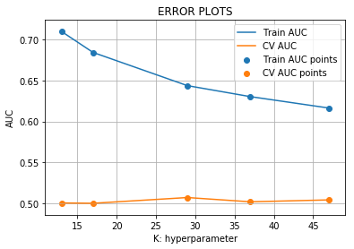

```python
import matplotlib.pyplot as plt
from sklearn.neighbors import KNeighborsClassifier
from sklearn.metrics import roc_auc_score

train_auc = []
cv_auc = []
K = [13, 17, 29, 37, 47] #Choosing only odd numbers as even 'K' will lead to complications.
for i in K:
    neigh = KNeighborsClassifier(n_neighbors=i, algorithm='brute')
    neigh.fit(X_tr, y_train)

    y_train_pred = batch_predict(neigh, X_tr)
    y_cv_pred = batch_predict(neigh, X_cr)

    # roc_auc_score(y_true, y_score) the 2nd parameter should be probability estimates of the positive class
    # not the predicted outputs
    train_auc.append(roc_auc_score(y_train,y_train_pred))
    cv_auc.append(roc_auc_score(y_cv, y_cv_pred))

plt.plot(K, train_auc, label='Train AUC')
plt.plot(K, cv_auc, label='CV AUC')

plt.scatter(K, train_auc, label='Train AUC points')
plt.scatter(K, cv_auc, label='CV AUC points')

plt.legend()
plt.xlabel("K: hyperparameter")
plt.ylabel("AUC")
plt.title("ERROR PLOTS")
plt.grid()
plt.show()
```

```
AUC of Train Data: 0.644
AUC of Test Data: 0.501
```

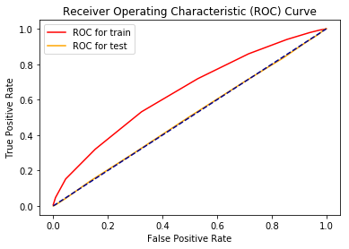

```python
#Citation: plot roc auc curve
#url: https://stackabuse.com/understanding-roc-curves-with-python/
best_k = 29

from sklearn.metrics import roc_curve, auc
from sklearn.metrics import roc_curve
from sklearn.metrics import roc_auc_score
from matplotlib import pyplot

neigh = KNeighborsClassifier(n_neighbors=best_k, algorithm='brute')
neigh.fit(X_tr, y_train)

def plot_roc_curve(test_fpr, test_tpr, train_fpr, train_tpr):
    plt.plot(train_fpr, train_tpr, color='red', label='ROC for train')
    plt.plot(test_fpr, test_tpr, color='orange', label='ROC for test')
    plt.plot([0, 1], [0, 1], color='darkblue', linestyle='--')
    plt.xlabel('False Positive Rate')
    plt.ylabel('True Positive Rate')
    plt.title('Receiver Operating Characteristic (ROC) Curve')
    plt.legend()
    plt.show()

y_test_pred = neigh.predict_proba(X_te)
y_test_pred = y_test_pred[:, 1]

y_train_pred = neigh.predict_proba(X_tr)
y_train_pred = y_train_pred[:, 1]

auc_train = roc_auc_score(y_train, y_train_pred)
print('AUC of Train Data: %.3f' % auc_train)

auc_test = roc_auc_score(y_test, y_test_pred)
print('AUC of Test Data: %.3f' % auc_test)

train_fpr, train_tpr, train_thresholds = roc_curve(y_train, y_train_pred)
test_fpr, test_tpr, test_thresholds = roc_curve(y_test, y_test_pred)

plot_roc_curve(test_fpr, test_tpr, train_fpr, train_tpr)
```

```python
# we are writing our own function for predict, with defined thresould
# we will pick a threshold that will give the least fpr
def predict(proba, threshould, fpr, tpr):

    t = threshould[np.argmax(tpr*(1-fpr))]

    # (tpr*(1-fpr)) will be maximum if your fpr is very low and tpr is very high

    print("the maximum value of tpr*(1-fpr)", max(tpr*(1-fpr)), "for threshold", np.round(t,3))
    predictions = []
    for i in proba:
        if i>=t:
            predictions.append(1)
        else:
            predictions.append(0)
    return predictions
```

```
Train confusion matrix
the maximum value of tpr*(1-fpr) 0.2491376921138826 for threshold 0.828
```

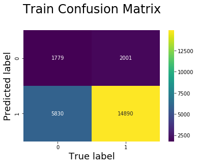

```
Test confusion matrix
the maximum value of tpr*(1-fpr) 0.24994602767416998 for threshold 0.862
```

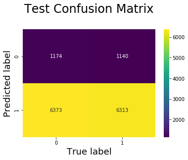

```python
from sklearn.metrics import confusion_matrix

print("Train confusion matrix")
cm_train = confusion_matrix(y_train, predict(y_train_pred, train_thresholds, train_fpr, train_fpr))

class_names = ['negative','positive']
sns.heatmap(cm_train, annot=True, fmt='d',cmap='viridis')
plt.ylabel('Predicted label',size=18)
plt.xlabel('True label',size=18)
plt.title("Train Confusion Matrix\n",size=24)
plt.show()

print("Test confusion matrix")
cm_test = confusion_matrix(y_test, predict(y_test_pred, test_thresholds, test_fpr, test_fpr))

class_names = ['negative','positive']
sns.heatmap(cm_test, annot=True, fmt='d',cmap='viridis')
plt.ylabel('Predicted label',size=18)
plt.xlabel('True label',size=18)
plt.title("Test Confusion Matrix\n",size=24)
plt.show()
```

## Set 2: categorical, numerical features + project_title(TFIDF)+ preprocessed_essay (TFIDF)

```python
def batch_predict(clf, data):
    # roc_auc_score(y_true, y_score) the 2nd parameter should be probability estimates of the positive class
    # not the predicted outputs

    y_data_pred = []
    tr_loop = data.shape[0] - data.shape[0]%1000
    # consider you X_tr shape is 49041, then your cr_loop will be 49041 - 49041%1000 = 49000
    # in this for loop we will iterate unti the last 1000 multiplier
    for i in range(0, tr_loop, 1000):
        y_data_pred.extend(clf.predict_proba(data[i:i+1000])[:,1])
    # we will be predicting for the last data points
    y_data_pred.extend(clf.predict_proba(data[tr_loop:])[:,1])

    return y_data_pred
```

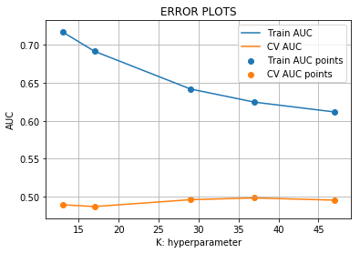

```python
import matplotlib.pyplot as plt
from sklearn.neighbors import KNeighborsClassifier
from sklearn.metrics import roc_auc_score

train_auc = []
cv_auc = []
K = [13, 17, 29, 37, 47] #Choosing only odd numbers as even 'K' will lead to complications.
for i in K:
    neigh = KNeighborsClassifier(n_neighbors=i, algorithm='brute')
    neigh.fit(X_tr, y_train)

    y_train_pred = batch_predict(neigh, X_tr)
    y_cv_pred = batch_predict(neigh, X_cr)

    # roc_auc_score(y_true, y_score) the 2nd parameter should be probability estimates of the positive class
    # not the predicted outputs
    train_auc.append(roc_auc_score(y_train,y_train_pred))
    cv_auc.append(roc_auc_score(y_cv, y_cv_pred))

plt.plot(K, train_auc, label='Train AUC')
plt.plot(K, cv_auc, label='CV AUC')

plt.scatter(K, train_auc, label='Train AUC points')
plt.scatter(K, cv_auc, label='CV AUC points')

plt.legend()
plt.xlabel("K: hyperparameter")
plt.ylabel("AUC")
plt.title("ERROR PLOTS")
plt.grid()
plt.show()
```

```
AUC of Train Data: 0.625
AUC of Test Data: 0.504
```

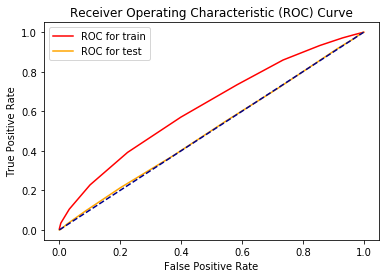

```python
#Citation: plot roc auc curve
#url: https://stackabuse.com/understanding-roc-curves-with-python/
best_k = 37

from sklearn.metrics import roc_curve, auc
from sklearn.metrics import roc_curve
from sklearn.metrics import roc_auc_score
from matplotlib import pyplot

neigh = KNeighborsClassifier(n_neighbors=best_k, algorithm='brute')
neigh.fit(X_tr, y_train)

def plot_roc_curve(test_fpr, test_tpr, train_fpr, train_tpr):
    plt.plot(train_fpr, train_tpr, color='red', label='ROC for train')
    plt.plot(test_fpr, test_tpr, color='orange', label='ROC for test')
    plt.plot([0, 1], [0, 1], color='darkblue', linestyle='--')
    plt.xlabel('False Positive Rate')
    plt.ylabel('True Positive Rate')
    plt.title('Receiver Operating Characteristic (ROC) Curve')
    plt.legend()
    plt.show()

y_test_pred = neigh.predict_proba(X_te)
y_test_pred = y_test_pred[:, 1]

y_train_pred = neigh.predict_proba(X_tr)
y_train_pred = y_train_pred[:, 1]

auc_train = roc_auc_score(y_train, y_train_pred)
print('AUC of Train Data: %.3f' % auc_train)

auc_test = roc_auc_score(y_test, y_test_pred)
print('AUC of Test Data: %.3f' % auc_test)

train_fpr, train_tpr, train_thresholds = roc_curve(y_train, y_train_pred)
test_fpr, test_tpr, test_thresholds = roc_curve(y_test, y_test_pred)

plot_roc_curve(test_fpr, test_tpr, train_fpr, train_tpr)
```

```python
# we are writing our own function for predict, with defined thresould
# we will pick a threshold that will give the least fpr
def predict(proba, threshould, fpr, tpr):

    t = threshould[np.argmax(tpr*(1-fpr))]

    # (tpr*(1-fpr)) will be maximum if your fpr is very low and tpr is very high

    print("the maximum value of tpr*(1-fpr)", max(tpr*(1-fpr)), "for threshold", np.round(t,3))
    predictions = []
    for i in proba:
        if i>=t:
            predictions.append(1)
        else:
            predictions.append(0)
    return predictions
```

```
Train confusion matrix
the maximum value of tpr*(1-fpr) 0.24292265054169815 for threshold 0.838
```

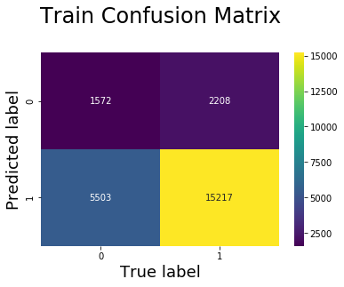

```
Test confusion matrix
the maximum value of tpr*(1-fpr) 0.24753015913805634 for threshold 0.865
```

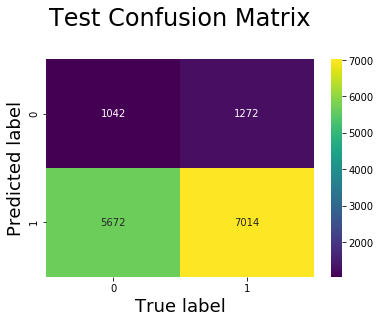

```python
from sklearn.metrics import confusion_matrix

print("Train confusion matrix")
cm_train = confusion_matrix(y_train, predict(y_train_pred, train_thresholds, train_fpr, train_fpr))

class_names = ['negative','positive']
sns.heatmap(cm_train, annot=True, fmt='d',cmap='viridis')
plt.ylabel('Predicted label',size=18)
plt.xlabel('True label',size=18)
plt.title("Train Confusion Matrix\n",size=24)
plt.show()

print("Test confusion matrix")
cm_test = confusion_matrix(y_test, predict(y_test_pred, test_thresholds, test_fpr, test_fpr))

class_names = ['negative','positive']
sns.heatmap(cm_test, annot=True, fmt='d',cmap='viridis')
plt.ylabel('Predicted label',size=18)
plt.xlabel('True label',size=18)
plt.title("Test Confusion Matrix\n",size=24)
plt.show()
```

# **Selecting the 'K' best features using SelectKBest for Set 2**

```python
import warnings
warnings.filterwarnings('ignore')

from sklearn.feature_selection import SelectKBest
kbest = SelectKBest(k=2000) #selecting 2000 best features
kbest_tr = kbest.fit_transform(X_tr,y_train)
kbest_cv = kbest.fit_transform(X_cr,y_cv)
kbest_te = kbest.fit_transform(X_te,y_test)
```

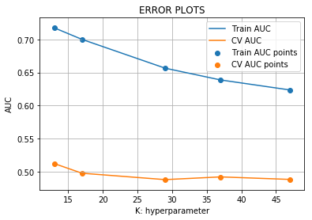

```python
train_auc = []
cv_auc = []
K = [13, 17, 29, 37, 47] #Choosing only odd numbers as even 'K' will lead to complications.
for i in K:
    neigh = KNeighborsClassifier(n_neighbors=i, algorithm='brute')
    neigh.fit(kbest_tr, y_train)

    y_train_pred = batch_predict(neigh, kbest_tr)
    y_cv_pred = batch_predict(neigh, kbest_cv)

    # roc_auc_score(y_true, y_score) the 2nd parameter should be probability estimates of the positive class
    # not the predicted outputs
    train_auc.append(roc_auc_score(y_train,y_train_pred))
    cv_auc.append(roc_auc_score(y_cv, y_cv_pred))

plt.plot(K, train_auc, label='Train AUC')
plt.plot(K, cv_auc, label='CV AUC')

plt.scatter(K, train_auc, label='Train AUC points')
plt.scatter(K, cv_auc, label='CV AUC points')

plt.legend()
plt.xlabel("K: hyperparameter")
plt.ylabel("AUC")
plt.title("ERROR PLOTS")
plt.grid()
plt.show()
```

```
AUC of Train Data: 0.718
AUC of Test Data: 0.500
```

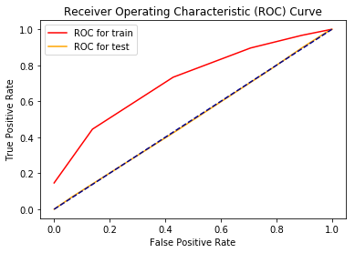

```python
#Citation: plot roc auc curve
#url: https://stackabuse.com/understanding-roc-curves-with-python/
best_k = 13

from sklearn.metrics import roc_curve, auc
from sklearn.metrics import roc_curve
from sklearn.metrics import roc_auc_score
from matplotlib import pyplot

neigh = KNeighborsClassifier(n_neighbors=best_k, algorithm='brute')
neigh.fit(kbest_tr, y_train)

def plot_roc_curve(test_fpr, test_tpr, train_fpr, train_tpr):
    plt.plot(train_fpr, train_tpr, color='red', label='ROC for train')
    plt.plot(test_fpr, test_tpr, color='orange', label='ROC for test')
    plt.plot([0, 1], [0, 1], color='darkblue', linestyle='--')
    plt.xlabel('False Positive Rate')
    plt.ylabel('True Positive Rate')
    plt.title('Receiver Operating Characteristic (ROC) Curve')
    plt.legend()
    plt.show()

y_test_pred = neigh.predict_proba(kbest_te)
y_test_pred = y_test_pred[:, 1]

y_train_pred = neigh.predict_proba(kbest_tr)
y_train_pred = y_train_pred[:, 1]

auc_train = roc_auc_score(y_train, y_train_pred)
print('AUC of Train Data: %.3f' % auc_train)

auc_test = roc_auc_score(y_test, y_test_pred)
print('AUC of Test Data: %.3f' % auc_test)

train_fpr, train_tpr, train_thresholds = roc_curve(y_train, y_train_pred)
test_fpr, test_tpr, test_thresholds = roc_curve(y_test, y_test_pred)

plot_roc_curve(test_fpr, test_tpr, train_fpr, train_tpr)
```

```
Train confusion matrix
the maximum value of tpr*(1-fpr) 0.24489795918367344 for threshold 0.846
```

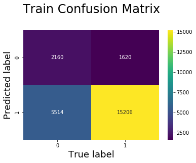

```
Test confusion matrix
the maximum value of tpr*(1-fpr) 0.24689220251163677 for threshold 0.923
```

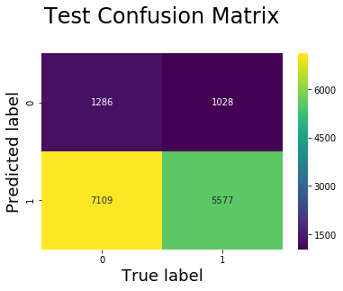

```python
from sklearn.metrics import confusion_matrix

print("Train confusion matrix")
cm_train = confusion_matrix(y_train, predict(y_train_pred, train_thresholds, train_fpr, train_fpr))

class_names = ['negative','positive']
sns.heatmap(cm_train, annot=True, fmt='d',cmap='viridis')
plt.ylabel('Predicted label',size=18)
plt.xlabel('True label',size=18)
plt.title("Train Confusion Matrix\n",size=24)
plt.show()

print("Test confusion matrix")
cm_test = confusion_matrix(y_test, predict(y_test_pred, test_thresholds, test_fpr, test_fpr))

class_names = ['negative','positive']
sns.heatmap(cm_test, annot=True, fmt='d',cmap='viridis')
plt.ylabel('Predicted label',size=18)
plt.xlabel('True label',size=18)
plt.title("Test Confusion Matrix\n",size=24)
plt.show()
```

## Set 3: categorical, numerical features + project_title(AVG W2V)+ preprocessed_essay (AVG W2V)

```python
def batch_predict(clf, data):
    # roc_auc_score(y_true, y_score) the 2nd parameter should be probability estimates of the positive class
    # not the predicted outputs

    y_data_pred = []
    tr_loop = data.shape[0] - data.shape[0]%1000
    # consider you X_tr shape is 49041, then your cr_loop will be 49041 - 49041%1000 = 49000
    # in this for loop we will iterate unti the last 1000 multiplier
    for i in range(0, tr_loop, 1000):
        y_data_pred.extend(clf.predict_proba(data[i:i+1000])[:,1])
    # we will be predicting for the last data points
    y_data_pred.extend(clf.predict_proba(data[tr_loop:])[:,1])

    return y_data_pred
```

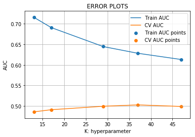

```python
import matplotlib.pyplot as plt
from sklearn.neighbors import KNeighborsClassifier
from sklearn.metrics import roc_auc_score

train_auc = []
cv_auc = []
K = [13, 17, 29, 37, 47] #Choosing only odd numbers as even 'K' will lead to complications.
for i in K:
    neigh = KNeighborsClassifier(n_neighbors=i, algorithm='brute')
    neigh.fit(X_tr, y_train)

    y_train_pred = batch_predict(neigh, X_tr)
    y_cv_pred = batch_predict(neigh, X_cr)

    # roc_auc_score(y_true, y_score) the 2nd parameter should be probability estimates of the positive class
    # not the predicted outputs
    train_auc.append(roc_auc_score(y_train,y_train_pred))
    cv_auc.append(roc_auc_score(y_cv, y_cv_pred))

plt.plot(K, train_auc, label='Train AUC')
plt.plot(K, cv_auc, label='CV AUC')

plt.scatter(K, train_auc, label='Train AUC points')
plt.scatter(K, cv_auc, label='CV AUC points')

plt.legend()
plt.xlabel("K: hyperparameter")
plt.ylabel("AUC")
plt.title("ERROR PLOTS")
plt.grid()
plt.show()
```

```
AUC of Train Data: 0.628
AUC of Test Data: 0.505
```

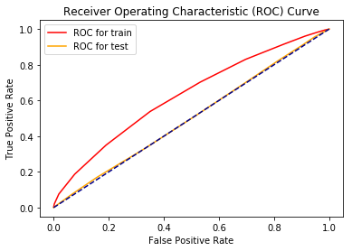

```python
#Citation: plot roc auc curve
#url: https://stackabuse.com/understanding-roc-curves-with-python/
best_k = 37

from sklearn.metrics import roc_curve, auc
from sklearn.metrics import roc_curve
from sklearn.metrics import roc_auc_score
from matplotlib import pyplot

neigh = KNeighborsClassifier(n_neighbors=best_k, algorithm='brute')
neigh.fit(X_tr, y_train)

def plot_roc_curve(test_fpr, test_tpr, train_fpr, train_tpr):
    plt.plot(train_fpr, train_tpr, color='red', label='ROC for train')
    plt.plot(test_fpr, test_tpr, color='orange', label='ROC for test')
    plt.plot([0, 1], [0, 1], color='darkblue', linestyle='--')
    plt.xlabel('False Positive Rate')
    plt.ylabel('True Positive Rate')
    plt.title('Receiver Operating Characteristic (ROC) Curve')
    plt.legend()
    plt.show()

y_test_pred = neigh.predict_proba(X_te)
y_test_pred = y_test_pred[:, 1]

y_train_pred = neigh.predict_proba(X_tr)
y_train_pred = y_train_pred[:, 1]

auc_train = roc_auc_score(y_train, y_train_pred)
print('AUC of Train Data: %.3f' % auc_train)

auc_test = roc_auc_score(y_test, y_test_pred)
print('AUC of Test Data: %.3f' % auc_test)

train_fpr, train_tpr, train_thresholds = roc_curve(y_train, y_train_pred)
test_fpr, test_tpr, test_thresholds = roc_curve(y_test, y_test_pred)

plot_roc_curve(test_fpr, test_tpr, train_fpr, train_tpr)
```

```python
# we are writing our own function for predict, with defined thresould
# we will pick a threshold that will give the least fpr
def predict(proba, threshould, fpr, tpr):

    t = threshould[np.argmax(tpr*(1-fpr))]

    # (tpr*(1-fpr)) will be maximum if your fpr is very low and tpr is very high

    print("the maximum value of tpr*(1-fpr)", max(tpr*(1-fpr)), "for threshold", np.round(t,3))
    predictions = []
    for i in proba:
        if i>=t:
            predictions.append(1)
        else:
            predictions.append(0)
    return predictions
```

```
Train confusion matrix
the maximum value of tpr*(1-fpr) 0.2489753226393438 for threshold 0.838
```

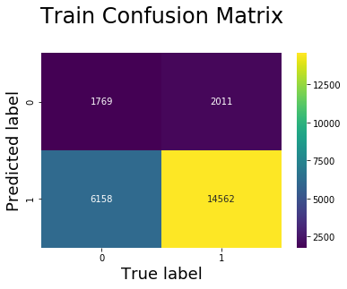

```
Test confusion matrix
the maximum value of tpr*(1-fpr) 0.2498205280099563 for threshold 0.865
```

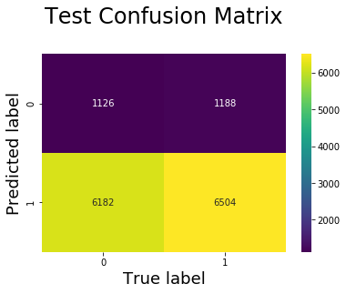

```python
from sklearn.metrics import confusion_matrix

print("Train confusion matrix")
cm_train = confusion_matrix(y_train, predict(y_train_pred, train_thresholds, train_fpr, train_fpr))

class_names = ['negative','positive']
sns.heatmap(cm_train, annot=True, fmt='d',cmap='viridis')
plt.ylabel('Predicted label',size=18)
plt.xlabel('True label',size=18)
plt.title("Train Confusion Matrix\n",size=24)
plt.show()

print("Test confusion matrix")
cm_test = confusion_matrix(y_test, predict(y_test_pred, test_thresholds, test_fpr, test_fpr))

class_names = ['negative','positive']
sns.heatmap(cm_test, annot=True, fmt='d',cmap='viridis')
plt.ylabel('Predicted label',size=18)
plt.xlabel('True label',size=18)
plt.title("Test Confusion Matrix\n",size=24)
plt.show()
```

## Set 4: categorical, numerical features + project_title(TFIDF W2V)+ preprocessed_essay (TFIDF W2V)

```python
def batch_predict(clf, data):
    # roc_auc_score(y_true, y_score) the 2nd parameter should be probability estimates of the positive class
    # not the predicted outputs

    y_data_pred = []
    tr_loop = data.shape[0] - data.shape[0]%1000
    # consider you X_tr shape is 49041, then your cr_loop will be 49041 - 49041%1000 = 49000
    # in this for loop we will iterate unti the last 1000 multiplier
    for i in range(0, tr_loop, 1000):
        y_data_pred.extend(clf.predict_proba(data[i:i+1000])[:,1])
    # we will be predicting for the last data points
    y_data_pred.extend(clf.predict_proba(data[tr_loop:])[:,1])

    return y_data_pred
```

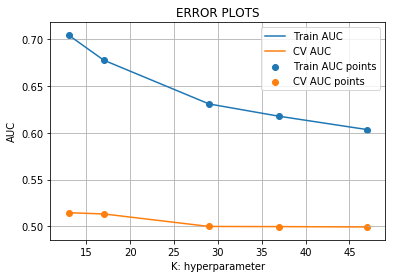

```python
import matplotlib.pyplot as plt
from sklearn.neighbors import KNeighborsClassifier
from sklearn.metrics import roc_auc_score

train_auc = []
cv_auc = []
K = [13, 17, 29, 37, 47] #Choosing only odd numbers as even 'K' will lead to complications.
for i in K:
    neigh = KNeighborsClassifier(n_neighbors=i, algorithm='brute')
    neigh.fit(X_tr, y_train)

    y_train_pred = batch_predict(neigh, X_tr)
    y_cv_pred = batch_predict(neigh, X_cr)

    # roc_auc_score(y_true, y_score) the 2nd parameter should be probability estimates of the positive class
    # not the predicted outputs
    train_auc.append(roc_auc_score(y_train,y_train_pred))
    cv_auc.append(roc_auc_score(y_cv, y_cv_pred))

plt.plot(K, train_auc, label='Train AUC')
plt.plot(K, cv_auc, label='CV AUC')

plt.scatter(K, train_auc, label='Train AUC points')
plt.scatter(K, cv_auc, label='CV AUC points')

plt.legend()
plt.xlabel("K: hyperparameter")
plt.ylabel("AUC")
plt.title("ERROR PLOTS")
plt.grid()
plt.show()
```

```
AUC of Train Data: 0.704
AUC of Test Data: 0.504
```

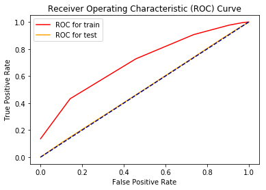

```python
#Citation: plot roc auc curve
#url: https://stackabuse.com/understanding-roc-curves-with-python/
best_k = 13

from sklearn.metrics import roc_curve, auc
from sklearn.metrics import roc_curve
from sklearn.metrics import roc_auc_score
from matplotlib import pyplot

neigh = KNeighborsClassifier(n_neighbors=best_k, algorithm='brute')
neigh.fit(X_tr, y_train)

def plot_roc_curve(test_fpr, test_tpr, train_fpr, train_tpr):
    plt.plot(train_fpr, train_tpr, color='red', label='ROC for train')
    plt.plot(test_fpr, test_tpr, color='orange', label='ROC for test')
    plt.plot([0, 1], [0, 1], color='darkblue', linestyle='--')
    plt.xlabel('False Positive Rate')
    plt.ylabel('True Positive Rate')
    plt.title('Receiver Operating Characteristic (ROC) Curve')
    plt.legend()
    plt.show()

y_test_pred = neigh.predict_proba(X_te)
y_test_pred = y_test_pred[:, 1]

y_train_pred = neigh.predict_proba(X_tr)
y_train_pred = y_train_pred[:, 1]

auc_train = roc_auc_score(y_train, y_train_pred)
print('AUC of Train Data: %.3f' % auc_train)

auc_test = roc_auc_score(y_test, y_test_pred)
print('AUC of Test Data: %.3f' % auc_test)

train_fpr, train_tpr, train_thresholds = roc_curve(y_train, y_train_pred)
test_fpr, test_tpr, test_thresholds = roc_curve(y_test, y_test_pred)

plot_roc_curve(test_fpr, test_tpr, train_fpr, train_tpr)
```

```python
# we are writing our own function for predict, with defined thresould
# we will pick a threshold that will give the least fpr
def predict(proba, threshould, fpr, tpr):

    t = threshould[np.argmax(tpr*(1-fpr))]

    # (tpr*(1-fpr)) will be maximum if your fpr is very low and tpr is very high

    print("the maximum value of tpr*(1-fpr)", max(tpr*(1-fpr)), "for threshold", np.round(t,3))
    predictions = []
    for i in proba:
        if i>=t:
            predictions.append(1)
        else:
            predictions.append(0)
    return predictions
```

```
Train confusion matrix
the maximum value of tpr*(1-fpr) 0.24825284846448864 for threshold 0.846
```

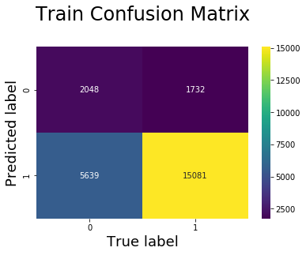

```
Test confusion matrix
the maximum value of tpr*(1-fpr) 0.23678593118883293 for threshold 0.923
```

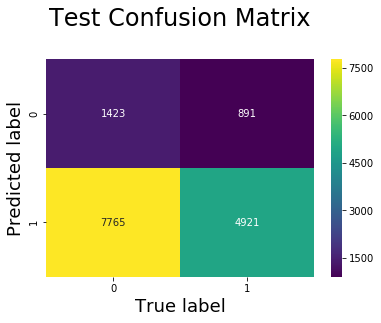

```python
from sklearn.metrics import confusion_matrix

print("Train confusion matrix")
cm_train = confusion_matrix(y_train, predict(y_train_pred, train_thresholds, train_fpr, train_fpr))

class_names = ['negative','positive']
sns.heatmap(cm_train, annot=True, fmt='d',cmap='viridis')
plt.ylabel('Predicted label',size=18)
plt.xlabel('True label',size=18)
plt.title("Train Confusion Matrix\n",size=24)
plt.show()

print("Test confusion matrix")
cm_test = confusion_matrix(y_test, predict(y_test_pred, test_thresholds, test_fpr, test_fpr))

class_names = ['negative','positive']
sns.heatmap(cm_test, annot=True, fmt='d',cmap='viridis')
plt.ylabel('Predicted label',size=18)
plt.xlabel('True label',size=18)
plt.title("Test Confusion Matrix\n",size=24)
plt.show()
```

# 8. Conclusion

```python
#Citation:
#url: http://zetcode.com/python/prettytable/

from prettytable import PrettyTable

x = PrettyTable()

x.field_names = ["Index", "Vectorizer", "Model", "Hyper-parameter", "AUC"]

x.add_row(["Set 1", "Bag Of Words", "Brute", 29, 0.501])
x.add_row(["Set 2", "TF-IDF", "Brute", 37, 0.504])
x.add_row(["Set 2 (SelectKBest)", "TF-IDF", "Brute", 13, 0.500])
x.add_row(["Set 3", "AVG W2V", "Brute", 37, 0.505])
x.add_row(["Set 4", "TF-IDF AVG W2V", "Brute", 13, 0.504])

print(x)
```

```
+---------------------+----------------+-------+-----------------+-------+
|        Index        |   Vectorizer   | Model | Hyper-parameter |  AUC  |
+---------------------+----------------+-------+-----------------+-------+
|        Set 1        |  Bag Of Words  | Brute |        29       | 0.501 |
|        Set 2        |     TF-IDF     | Brute |        37       | 0.504 |
| Set 2 (SelectKBest) |     TF-IDF     | Brute |        13       |  0.5  |
|        Set 3        |    AVG W2V     | Brute |        37       | 0.505 |
|        Set 4        | TF-IDF AVG W2V | Brute |        13       | 0.504 |
+---------------------+----------------+-------+-----------------+-------+
```